# LR term pruning — choosing a common reduced predictor set

Rank standardized coefficients (|β_z|) per veg_fire class; compare area-weight transforms for global importance

Author

Iván Barberá

Published

June 25, 2026

```r
library(data.table)
library(tidyverse)
library(scales)
library(knitr)

models_dir <- "../models"     # tracked per-class coefficient CSVs (block, term, coefficient, coef_std)
theme_set(theme_minimal(base_size = 11))

# coef_std = β · sd(raw column)  (02-model_fitting.R) == the standardized effect size |β_z|.
# Same 129-term universe & order in every class file.
block_lvls <- c("focal", "prev", "pairs", "sameband", "cross_idx", "cross_band")
```

# 1 Context & constraints (read first)

**Why prune.** The burn-probability model is applied per Landsat observation over ~150 date-mosaicked scenes per tile in the GEE prediction step (`workflow/03-bp_ts_metrics.py`). Profiling (`docs/03-bpts.md §8`) showed the **130-term elastic-net LR dominates per-tile compute** — the per-term band selects / multiplies / sums, and the computation-graph “plumbing” they generate, scale with the term count, while the clever time-series array metrics are <1% of cost. So fewer terms ⇒ cheaper prediction across all 248 tiles × 27 years. This notebook decides *which* terms to keep.

**The hard constraint — one shared set across classes.** The model is fit **per `veg_fire` class** (23 fittable classes; elastic-net already zeros ~half the terms, but a *different* half per class, so their union is nearly the full 129). We deliberately want a **single predictor set used by every class** — the surviving terms keep their own per-class coefficients, but the *set itself is identical* — so the deployed GEE coefficient image stays a uniform fixed block of bands. The question is therefore not “which terms matter for class X” but “which matter *across the landscape*”, answered here by ranking + area-weighted aggregation.

**The interaction–main hierarchy constraint.** Of the 129 terms, 86 are interactions (`A__B`). The fit centers each interaction’s factors and folds that centering back into the main slopes (`02-model_fitting.R`); consequently a kept interaction’s two mains **must also be kept**, or the fold-back has nowhere to place its adjustment. So we **close the hierarchy**: any kept `A__B` forces mains `A` and `B` into the set (also the statistically standard choice). Here this expands the nominal top-P by only 0–2 terms, because the top interactions’ mains are themselves high-ranked.

**Method.** (1) rank each class’s terms by the standardized coefficient `|β_z|` = `coef_std` (`|β|·sd` of the raw design column — an effect size comparable across predictors of different scales); (2) normalize each class’s `|β_z|` to **sum 1**, so a class with large-magnitude coefficients doesn’t dominate by scale; (3) aggregate to a **global importance** = `Σ_class (area_weight × normalized |β_z|)`, weighting classes by their **relative area in Argentina** so the shared set reflects the landscape that actually burns — comparing three smoothings (`area`, `√area`, `∛area`) since raw area lets a few huge classes dominate; (4) cut at the top-P and close the hierarchy.

**Validation (final section).** Each candidate P is refit (`scripts/refit_pruning_sweep.R`, reusing the same CV machinery) and compared to the full-129 model on **out-of-fold** AUC + Brier per class. We keep the smallest P whose area-weighted metrics match full within noise.

# 2 Load coefficients

```r
files <- Sys.glob(file.path(models_dir, "class_*_coefficients.csv"))
stopifnot(length(files) > 0)
coefs <- rbindlist(lapply(files, function(f) {
  cls <- as.integer(sub(".*class_0*(\\d+)_coefficients\\.csv$", "\\1", f))
  fread(f)[, class := cls]
}))
terms <- coefs[block != "(intercept)"]                 # 129 predictors (intercept has NA coef_std)
terms[, block := factor(block, levels = block_lvls)]
terms[, abs_z := abs(coef_std)][is.na(abs_z), abs_z := 0]
terms[, rank_in_class := frank(-abs_z, ties.method = "first"), by = class]
n_terms <- uniqueN(terms$term)
cat(sprintf("Loaded %d classes x %d predictor terms.\n", uniqueN(terms$class), n_terms))
```

```
Loaded 23 classes x 129 predictor terms.
```

# 3 Plot 1 — within-class ranked |β_z|

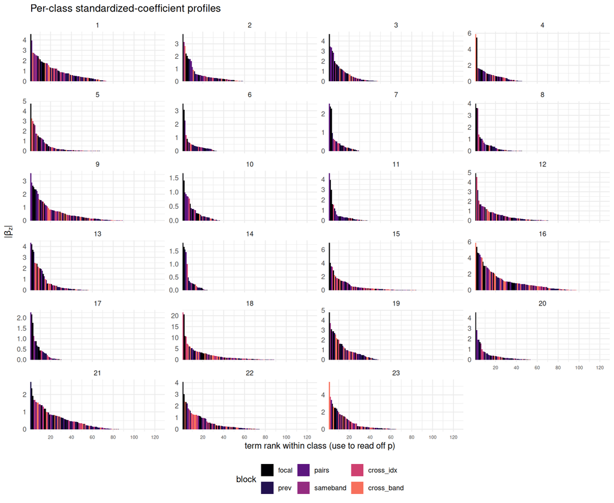

```r
ggplot(terms, aes(rank_in_class, abs_z, fill = block)) +
  geom_col(width = 1) +
  facet_wrap(~ class, scales = "free_y", ncol = 4) +
  scale_fill_viridis_d(option = "magma", end = 0.7) +
  scale_x_continuous(breaks = seq(0, n_terms, 20),
                     minor_breaks = seq(0, n_terms, 10), expand = c(0, 0)) +
  labs(x = "term rank within class (use to read off p)", y = expression("|" * beta[z] * "|"),
       fill = "block", title = "Per-class standardized-coefficient profiles") +
  theme(axis.text.x = element_text(size = 6),
        panel.grid.minor.x = element_line(linewidth = 0.3),
        panel.grid.major.x = element_line(linewidth = 0.5),
        legend.position = "bottom")
```

# 4 Class area weights (and their smoothings)

Absolute area per `veg_fire` class, computed correctly as **within-region class fraction × absolute region area**:

- *within-region fraction* — long-run (1999–2023) mapped area per region-class from the `areas_regiones` Google Sheet (same source as `land_cover_remap.qmd`), as a fraction of its region’s mapped total. The sheet’s raw areas are **not** comparable across regions, so we only use them for within-region composition.
- *absolute region area* — `config/region_areas.csv`, the geometry area (km²) of each of the 5 regions from the unbuffered regions FC (`scripts/region_areas.py`).

`area(veg_fire) = Σ_region region_area · (region-class mapped fraction)`, then normalized across the fittable classes. If the sheet is unreachable we fall back to equal weights.

```r
remap     <- fread(here::here("..", "config", "veg_fire_remap.csv"))
reg_area  <- fread(here::here("..", "config", "region_areas.csv"))   # region, region_num, area_km2
sheet_url <- "https://docs.google.com/spreadsheets/d/17ZShb8D0JaJw4nLvBDzt19xF6Fdg8lGHYs4Jogh0X1A"

area_by_vegfire <- tryCatch({
  library(googlesheets4); gs4_deauth()
  araw <- read_sheet(sheet_url, sheet = "areas_regiones")
  year_cols <- names(araw)[suppressWarnings(!is.na(as.integer(names(araw)))) &
                           suppressWarnings(as.integer(names(araw)) >= 1999) &
                           suppressWarnings(as.integer(names(araw)) <= 2023)]
  areas <- araw |>
    mutate(id_local = suppressWarnings(as.integer(unlist(id_local)))) |>
    filter(!is.na(id_local)) |>
    mutate(mean_area = rowMeans(pick(all_of(year_cols)), na.rm = TRUE)) |>
    select(region, id_local, mean_area)
  crosswalk <- as_tibble(remap) |>
    filter(!is.na(local_class), local_class != "") |>
    select(region, mb_class_raw, veg_fire, local_class) |>
    mutate(id_local = str_extract_all(local_class, "(?<=ID=)\\s*\\d+") |>
                      map(~ as.integer(str_trim(.x)))) |>
    unnest(id_local) |>
    distinct(region, mb_class_raw, veg_fire, id_local)
  # area per region-class, then within-region fraction, then × absolute region area.
  rc <- crosswalk |>
    left_join(areas, by = c("region", "id_local"), relationship = "many-to-many") |>
    group_by(region, mb_class_raw, veg_fire) |>
    summarise(mean_area = sum(mean_area, na.rm = TRUE), .groups = "drop") |>
    group_by(region) |>
    mutate(frac = mean_area / sum(mean_area, na.rm = TRUE)) |>
    ungroup() |>
    left_join(as_tibble(reg_area)[, c("region", "area_km2")], by = "region") |>
    mutate(abs_area = frac * area_km2)
  as.data.table(rc) |>
    (\(d) d[, .(area = sum(abs_area, na.rm = TRUE)), by = veg_fire])()
}, error = function(e) { message("Area sheet read failed: ", conditionMessage(e));
                         data.table(veg_fire = integer(), area = double()) })

classes <- sort(unique(terms$class))
aw <- merge(data.table(class = classes),
            area_by_vegfire[, .(class = veg_fire, area)], by = "class", all.x = TRUE)
aw[is.na(area), area := 0]
if (sum(aw$area) == 0) { message("EQUAL WEIGHTS fallback"); aw[, area := 1] }

# Classes with no crosswalked area (sheet id_local gaps — e.g. grassland_chaco, whose
# Chaco ids 42/43 are absent from the sheet) get the MEDIAN of the classes that do have
# area, so they still cast a typical (non-zero) vote instead of being silently dropped.
zero_cls <- aw[area == 0, class]
if (length(zero_cls)) {
  med <- median(aw[area > 0, area])
  aw[area == 0, area := med]
  message("Assigned median area (", round(med), " km2) to zero-area class(es): ",
          paste(zero_cls, collapse = ", "))
}

# transform = area^(1/K) THEN normalize to sum 1
aw[, w_area := area / sum(area)]
aw[, w_sqrt := sqrt(area) / sum(sqrt(area))]
aw[, w_cbrt := area^(1/3) / sum(area^(1/3))]
```

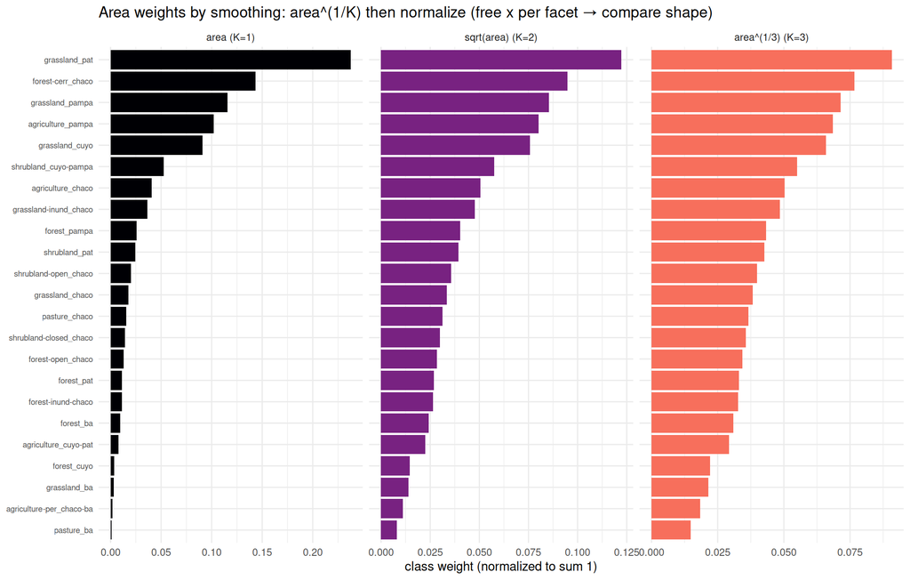

```r
# weight transform = area^(1/K) THEN normalize to sum 1 (K = 1, 2, 3).
vf_names <- unique(as.data.table(remap)[, .(class = veg_fire, name = veg_fire_name)])
awn <- merge(aw, vf_names, by = "class", all.x = TRUE)
awn[is.na(name), name := paste0("class_", class)]
awL <- melt(awn, id.vars = c("class", "name"),
            measure.vars = c("w_area", "w_sqrt", "w_cbrt"),
            variable.name = "transform", value.name = "weight")
awL[, transform := factor(transform, levels = c("w_area", "w_sqrt", "w_cbrt"),
       labels = c("area (K=1)", "sqrt(area) (K=2)", "area^(1/3) (K=3)"))]
awL[, name := factor(name, levels = awn[order(w_area), name])]   # y ordered by area (largest on top)

ggplot(awL, aes(weight, name, fill = transform)) +
  geom_col() +
  facet_wrap(~ transform, ncol = 3, scales = "free_x") +   # free weight axis → compare shape
  scale_fill_viridis_d(option = "magma", end = 0.7) +
  labs(x = "class weight (normalized to sum 1)", y = NULL,
       title = "Area weights by smoothing: area^(1/K) then normalize (free x per facet → compare shape)") +
  theme(axis.text.y = element_text(size = 7), legend.position = "none")
```

# 5 Global importance under each weight transform

`global(t) = Σ_c w_c · z_norm[c, t]`, with `z_norm` = within-class `|β_z|` normalized to sum 1, and `w_c` one of the three area smoothings. Each panel is independently ranked; minor grid every 20.

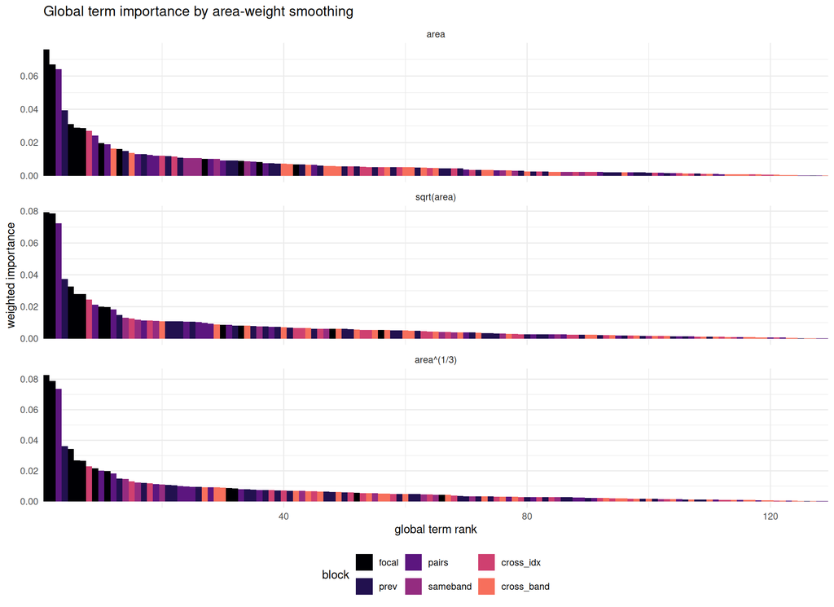

```r
g <- copy(terms)
g[, z_norm := { s <- sum(abs_z); if (s > 0) abs_z / s else abs_z }, by = class]
g <- merge(g, aw[, .(class, w_area, w_sqrt, w_cbrt)], by = "class")

imp <- g[, .(area       = sum(w_area * z_norm),
             `sqrt(area)`= sum(w_sqrt * z_norm),
             `area^(1/3)`= sum(w_cbrt * z_norm)), by = .(term, block)]
impL <- melt(imp, id.vars = c("term", "block"), variable.name = "weight", value.name = "importance")
impL[, weight := factor(weight, levels = c("area", "sqrt(area)", "area^(1/3)"))]
impL[, rank := frank(-importance, ties.method = "first"), by = weight]

ggplot(impL, aes(rank, importance, fill = block)) +
  geom_col(width = 1) +
  facet_wrap(~ weight, ncol = 1, scales = "free_y") +
  scale_fill_viridis_d(option = "magma", end = 0.7) +
  scale_x_continuous(breaks = seq(0, n_terms, 40),
                     minor_breaks = seq(0, n_terms, 20), expand = c(0, 0)) +
  labs(x = "global term rank", y = "weighted importance", fill = "block",
       title = "Global term importance by area-weight smoothing") +
  theme(panel.grid.minor.x = element_line(linewidth = 0.3),
        panel.grid.major.x = element_line(linewidth = 0.5), legend.position = "bottom")
```

## 5.1 Ranked term names per scheme

The same three rankings flipped so term **names** read on the y-axis, each prefixed with its rank (so every position is legible). Dashed lines mark the **p = 30 / 40 / 60** cuts. Each panel is ordered by its own scheme; compare which terms cross each cut.

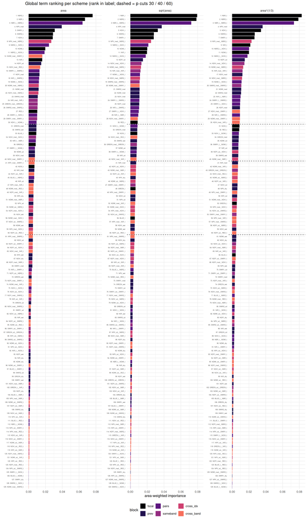

```r
gl <- copy(impL)
gl[, lab := sprintf("%3d. %s", rank, term)]
setorder(gl, weight, -importance)                    # rank 1 (highest) first within each scheme
gl[, key := paste(lab, weight, sep = "___")]
gl[, key := factor(key, levels = rev(unique(key)))]  # so rank 1 lands at the TOP

cuts <- n_terms - c(30, 40, 60) + 0.5                # discrete positions of the p-cuts (1=bottom)

ggplot(gl, aes(importance, key, fill = block)) +
  geom_col() +
  geom_hline(yintercept = cuts, linetype = "dashed", linewidth = 0.4) +
  facet_wrap(~ weight, scales = "free_y", ncol = 3) +
  scale_fill_viridis_d(option = "magma", end = 0.7) +
  scale_y_discrete(labels = function(x) sub("___.*$", "", x)) +
  labs(x = "area-weighted importance", y = NULL, fill = "block",
       title = "Global term ranking per scheme (rank in label; dashed = p cuts 30 / 40 / 60)") +
  theme(axis.text.y = element_text(size = 5), legend.position = "bottom")
```

```r
# How much do the three smoothings agree on the top-40? (overlap of the shared sets)
top40 <- impL[rank <= 40, .(term = list(term)), by = weight]
sets <- setNames(top40$term, as.character(top40$weight))
cat("Top-40 overlap across smoothings:\n")
```

```
Top-40 overlap across smoothings:
```

```r
cat("  area ∩ sqrt :", length(intersect(sets[["area"]], sets[["sqrt(area)"]])), "/ 40\n")
```

```
  area ∩ sqrt : 37 / 40
```

```r
cat("  area ∩ cbrt :", length(intersect(sets[["area"]], sets[["area^(1/3)"]])), "/ 40\n")
```

```
  area ∩ cbrt : 35 / 40
```

```r
cat("  sqrt ∩ cbrt :", length(intersect(sets[["sqrt(area)"]], sets[["area^(1/3)"]])), "/ 40\n")
```

```
  sqrt ∩ cbrt : 38 / 40
```

```r
cat("  in all three:", length(Reduce(intersect, sets)), "/ 40\n")
```

```
  in all three: 35 / 40
```

# 6 Write candidate reduced sets for refitting

Chosen scheme: **K = 3** (`area^(1/3)` smoothing). For each candidate `P` we take the top-P terms by global importance, then **close the interaction hierarchy** — any kept `A__B` term forces its mains `A`, `B` into the set, so the centering fold-back in `02-model_fitting.R` stays valid. The effective fitted set can therefore exceed the nominal P; both are recorded. Written to `config/pruning_terms.csv`, consumed by `scripts/refit_pruning_sweep.R`.

```r
SCHEME <- "area^(1/3)"                 # K = 3
P_TEST <- c(30, 40, 50, 60, 80)

rank_sel <- impL[weight == SCHEME][order(rank), .(term, rank)]
close_hier <- function(kept) {         # add main factors of any kept "A__B" interaction
  ints  <- kept[grepl("__", kept, fixed = TRUE)]
  mains <- unique(unlist(strsplit(ints, "__", fixed = TRUE)))
  union(kept, mains)
}
pruning_terms <- rbindlist(lapply(P_TEST, function(P) {
  topP <- rank_sel[rank <= P, term]
  full <- close_hier(topP)
  data.table(scheme = "area_cbrt_K3", P = P, term = full,
             nominal_rank = rank_sel$rank[match(full, rank_sel$term)],
             added_by_hierarchy = !(full %in% topP))
}))
fwrite(pruning_terms, here::here("..", "config", "pruning_terms.csv"))
pruning_terms[, .(nominal_P = P[1], effective = .N, added_for_hierarchy = sum(added_by_hierarchy)), by = P]
```

```
       P nominal_P effective added_for_hierarchy
   <num>     <num>     <int>               <int>
1:    30        30        32                   2
2:    40        40        41                   1
3:    50        50        51                   1
4:    60        60        61                   1
5:    80        80        80                   0
```

# 7 Reduced-model OOF metrics (after the refit sweep)

Populated once `scripts/refit_pruning_sweep.R` has run (it refits all classes per P and aggregates the per-class OOF metrics to `models-store/pruning/metrics_by_P.csv`). Brier (left, **lower** = better) and AUC (right, **higher** = better) per class; rows sorted by decreasing area weight; the **full-129** baseline is the `full` x-category.

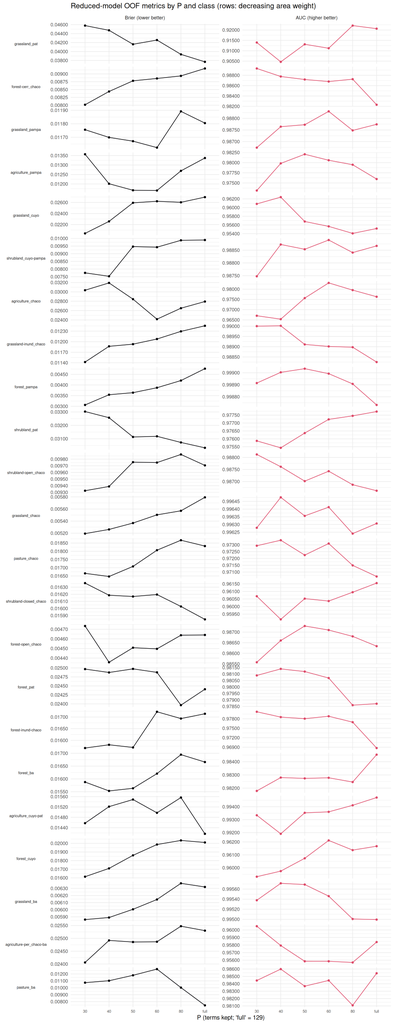

```r
mpath <- here::here("..", "models-store", "pruning", "metrics_by_P.csv")
if (!file.exists(mpath)) {
  cat("metrics_by_P.csv not found yet — run scripts/refit_pruning_sweep.R first.\n")
} else {
  met <- fread(mpath, colClasses = list(character = "P"))   # P incl. 'full'; veg_fire, cv_brier, cv_auc
  nm  <- unique(as.data.table(remap)[, .(veg_fire, name = veg_fire_name)])
  ord <- awn[order(-w_area), class]                          # decreasing area weight
  met <- merge(met, nm, by = "veg_fire", all.x = TRUE)
  met[, name := factor(name, levels = nm$name[match(ord, nm$veg_fire)])]
  met[, Px   := factor(P, levels = c(as.character(sort(P_TEST)), "full"))]
  mL <- melt(met, id.vars = c("name", "Px"), measure.vars = c("cv_brier", "cv_auc"),
             variable.name = "metric", value.name = "value")
  mL[, metric := factor(metric, levels = c("cv_brier", "cv_auc"),
                        labels = c("Brier (lower better)", "AUC (higher better)"))]
  ggplot(mL, aes(Px, value, color = metric, group = 1)) +
    geom_line() +
    geom_point(size = 1.3) +
    # facet_grid2 + independent="y": each Brier/AUC panel autoscales, so the tiny
    # across-P variation is visible (plain facet_grid shares y across the row's columns).
    ggh4x::facet_grid2(rows = vars(name), cols = vars(metric),
                       scales = "free_y", independent = "y", switch = "y") +
    scale_color_viridis_d(option = "magma", end = 0.6) +
    scale_y_continuous(labels = scales::label_number(accuracy = 1e-5)) +
    labs(x = "P (terms kept; 'full' = 129)", y = NULL,
         title = "Reduced-model OOF metrics by P and class (rows: decreasing area weight)") +
    theme(legend.position = "none", strip.placement = "outside",
          strip.text.y.left = element_text(angle = 0, size = 7),
          axis.text.x = element_text(size = 7))
}
```

## 7.1 All classes overlaid (one line per class)

Same metrics, no per-class facet: every `veg_fire` class overlaid as a coloured spaghetti line, faceted only by metric (each with its own y).

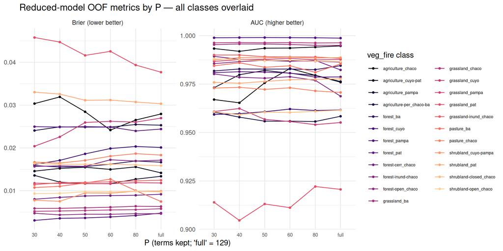

```r
mpath <- here::here("..", "models-store", "pruning", "metrics_by_P.csv")
if (!file.exists(mpath)) {
  cat("metrics_by_P.csv not found yet — run scripts/refit_pruning_sweep.R first.\n")
} else {
  met <- fread(mpath, colClasses = list(character = "P"))
  met[, Px := factor(P, levels = c(as.character(sort(P_TEST)), "full"))]
  mL <- melt(met, id.vars = c("veg_fire_name", "Px"), measure.vars = c("cv_brier", "cv_auc"),
             variable.name = "metric", value.name = "value")
  mL[, metric := factor(metric, levels = c("cv_brier", "cv_auc"),
                        labels = c("Brier (lower better)", "AUC (higher better)"))]
  ggplot(mL, aes(Px, value, color = veg_fire_name, group = veg_fire_name)) +
    geom_line() + geom_point(size = 1) +
    facet_wrap(~ metric, scales = "free_y") +
    scale_color_viridis_d(option = "magma", end = 0.9) +
    labs(x = "P (terms kept; 'full' = 129)", y = NULL, color = "veg_fire class",
         title = "Reduced-model OOF metrics by P — all classes overlaid") +
    theme(legend.text = element_text(size = 6), axis.text.x = element_text(size = 7))
}
```

## 7.2 Change vs full-129 (same spaghetti, as a difference)

Each line is `metric(P) − metric(full)`, so the full-129 baseline is the horizontal 0. ΔBrier < 0 = reduced model better (lower); ΔAUC > 0 = better. Flat lines ≈ lossless; a class that dips in ΔAUC (or rises in ΔBrier) is one the shared set underserves.

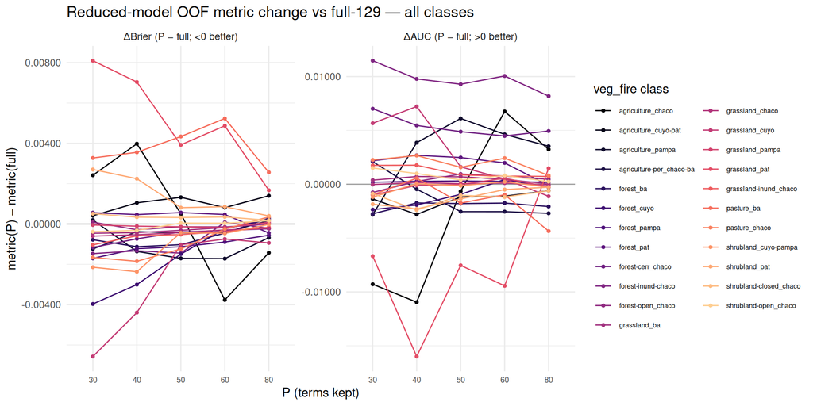

```r
mpath <- here::here("..", "models-store", "pruning", "metrics_by_P.csv")
if (!file.exists(mpath)) {
  cat("metrics_by_P.csv not found yet — run scripts/refit_pruning_sweep.R first.\n")
} else {
  met  <- fread(mpath, colClasses = list(character = "P"))
  base <- met[P == "full", .(veg_fire_name, b_full = cv_brier, a_full = cv_auc)]
  d    <- merge(met[P != "full"], base, by = "veg_fire_name")
  d[, `:=`(dBrier = cv_brier - b_full, dAUC = cv_auc - a_full)]
  d[, Px := factor(P, levels = as.character(sort(P_TEST)))]
  dL <- melt(d, id.vars = c("veg_fire_name", "Px"), measure.vars = c("dBrier", "dAUC"),
             variable.name = "metric", value.name = "delta")
  dL[, metric := factor(metric, levels = c("dBrier", "dAUC"),
                        labels = c("ΔBrier (P − full; <0 better)",
                                   "ΔAUC (P − full; >0 better)"))]
  ggplot(dL, aes(Px, delta, color = veg_fire_name, group = veg_fire_name)) +
    geom_hline(yintercept = 0, linewidth = 0.4, color = "grey60") +
    geom_line() + geom_point(size = 1) +
    facet_wrap(~ metric, scales = "free_y") +
    scale_color_viridis_d(option = "magma", end = 0.9) +
    scale_y_continuous(labels = scales::label_number(accuracy = 1e-5)) +
    labs(x = "P (terms kept)", y = "metric(P) − metric(full)", color = "veg_fire class",
         title = "Reduced-model OOF metric change vs full-129 — all classes") +
    theme(legend.text = element_text(size = 6), axis.text.x = element_text(size = 7))
}
```

## 7.3 % change vs full-129 (same spaghetti, relative)

`100 · (metric(P) − metric(full)) / metric(full)`. Normalizes the change by each class’s own baseline, so classes with very different absolute Brier/AUC are comparable. (AUC % moves are tiny since AUC ≈ 1; Brier % moves are larger because Brier is small.)

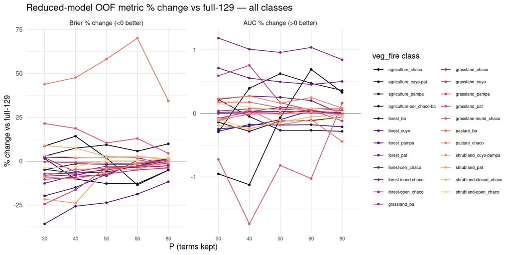

```r
mpath <- here::here("..", "models-store", "pruning", "metrics_by_P.csv")
if (!file.exists(mpath)) {
  cat("metrics_by_P.csv not found yet — run scripts/refit_pruning_sweep.R first.\n")
} else {
  met  <- fread(mpath, colClasses = list(character = "P"))
  base <- met[P == "full", .(veg_fire_name, b_full = cv_brier, a_full = cv_auc)]
  d    <- merge(met[P != "full"], base, by = "veg_fire_name")
  d[, `:=`(pBrier = 100 * (cv_brier - b_full) / b_full,
           pAUC   = 100 * (cv_auc   - a_full) / a_full)]
  d[, Px := factor(P, levels = as.character(sort(P_TEST)))]
  dL <- melt(d, id.vars = c("veg_fire_name", "Px"), measure.vars = c("pBrier", "pAUC"),
             variable.name = "metric", value.name = "pct")
  dL[, metric := factor(metric, levels = c("pBrier", "pAUC"),
                        labels = c("Brier % change (<0 better)", "AUC % change (>0 better)"))]
  ggplot(dL, aes(Px, pct, color = veg_fire_name, group = veg_fire_name)) +
    geom_hline(yintercept = 0, linewidth = 0.4, color = "grey60") +
    geom_line() + geom_point(size = 1) +
    facet_wrap(~ metric, scales = "free_y") +
    scale_color_viridis_d(option = "magma", end = 0.9) +
    labs(x = "P (terms kept)", y = "% change vs full-129", color = "veg_fire class",
         title = "Reduced-model OOF metric % change vs full-129 — all classes") +
    theme(legend.text = element_text(size = 6), axis.text.x = element_text(size = 7))
}
```

## 7.4 Area-weighted mean change vs full (decision summary)

Collapses the spaghetti to one number per P: the **area-weighted mean** of each metric’s change vs full-129 across the 23 classes, under each of the three area weightings (K=1 area, K=2 √area, K=3 ∛area). Heavier-tailed K (=1) leans on the big classes (so grassland_pat dominates); flatter K (=3) spreads weight to rarer classes. Both metrics side by side; 0 = full baseline.

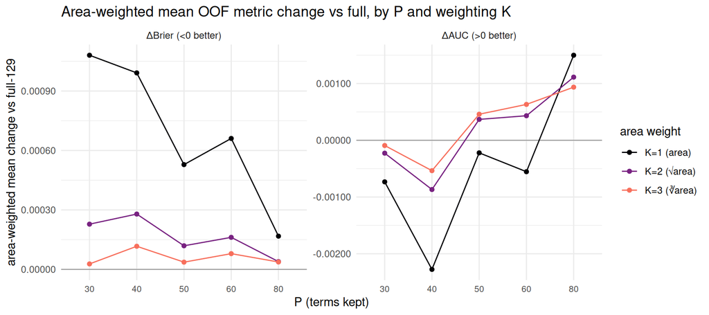

```r
mpath <- here::here("..", "models-store", "pruning", "metrics_by_P.csv")
if (!file.exists(mpath)) {
  cat("metrics_by_P.csv not found yet — run scripts/refit_pruning_sweep.R first.\n")
} else {
  met  <- fread(mpath, colClasses = list(character = "P"))
  base <- met[P == "full", .(veg_fire, b_full = cv_brier, a_full = cv_auc)]
  d    <- merge(met[P != "full"], base, by = "veg_fire")
  d[, `:=`(dBrier = cv_brier - b_full, dAUC = cv_auc - a_full)]
  d <- merge(d, aw[, .(veg_fire = class, w_area, w_sqrt, w_cbrt)], by = "veg_fire")
  dM <- melt(d, id.vars = c("veg_fire", "P", "w_area", "w_sqrt", "w_cbrt"),
             measure.vars = c("dBrier", "dAUC"), variable.name = "metric", value.name = "delta")
  wL <- melt(dM, id.vars = c("veg_fire", "P", "metric", "delta"),
             measure.vars = c("w_area", "w_sqrt", "w_cbrt"), variable.name = "K", value.name = "w")
  wavg <- wL[, .(wmean = sum(w * delta) / sum(w)), by = .(P, metric, K)]
  wavg[, K := factor(K, levels = c("w_area", "w_sqrt", "w_cbrt"),
                     labels = c("K=1 (area)", "K=2 (√area)", "K=3 (∛area)"))]
  wavg[, metric := factor(metric, levels = c("dBrier", "dAUC"),
                          labels = c("ΔBrier (<0 better)", "ΔAUC (>0 better)"))]
  wavg[, Px := factor(P, levels = as.character(sort(P_TEST)))]
  ggplot(wavg, aes(Px, wmean, color = K, group = K)) +
    geom_hline(yintercept = 0, linewidth = 0.4, color = "grey60") +
    geom_line() + geom_point(size = 1.5) +
    facet_wrap(~ metric, scales = "free_y") +
    scale_color_viridis_d(option = "magma", end = 0.7) +
    scale_y_continuous(labels = scales::label_number(accuracy = 1e-5)) +
    labs(x = "P (terms kept)", y = "area-weighted mean change vs full-129", color = "area weight",
         title = "Area-weighted mean OOF metric change vs full, by P and weighting K") +
    theme(axis.text.x = element_text(size = 8))
}
```